# Introduction

In ecommerce companies like online retails, customer segmentation is necessary in order to understand customers behaviors. It leverages aqcuired customer data like the one we have in our case, **transactions data** in order to divide customers into groups.

Our goal in this Notebook is to cluster our customers to get insights in:

- Increasing **revenue** (Knowing customers who present most of our revenue)
- Increasing customer **retention**
- Discovering **Trends and patterns**
- Defining **customers at risk**

We will do **RFM Analysis** as a first step and then **combine RFM with predictive algorithms (k-means)**.

RFM Analysis answers these questions:

- Who are our best customers?
- Who has the potential to be converted in more profitable customers?
- Which customers we must retain?
- Which group of customers is most likely to respond to our current campaign?

More about RFM [here](https://www.putler.com/rfm-analysis/).

# Import modules

```python
import pandas as pd
import numpy as np

import time, warnings
import datetime as dt

#modules for predictive models
import sklearn.cluster as cluster
from sklearn.cluster import KMeans
from sklearn.decomposition import PCA
#from sklearn.mixture import GMM

from sklearn.metrics import silhouette_samples, silhouette_score

#visualizations
import matplotlib.pyplot as plt
from pandas.plotting import scatter_matrix
%matplotlib inline
import seaborn as sns

warnings.filterwarnings("ignore")
```

# Get the Data

```python
#load the dataset
retail_df = pd.read_csv('OnlineRetail.csv',encoding='cp1252')
```

```python
retail_df.head(20)
```

|  | InvoiceNo | StockCode | Description | Quantity | InvoiceDate | UnitPrice | CustomerID | Country |
| --- | --- | --- | --- | --- | --- | --- | --- | --- |
| 0 | 536365 | 85123A | WHITE HANGING HEART T-LIGHT HOLDER | 6 | 12/1/2010 8:26 | 2.55 | 17850.0 | United Kingdom |
| 1 | 536365 | 71053 | WHITE METAL LANTERN | 6 | 12/1/2010 8:26 | 3.39 | 17850.0 | United Kingdom |
| 2 | 536365 | 84406B | CREAM CUPID HEARTS COAT HANGER | 8 | 12/1/2010 8:26 | 2.75 | 17850.0 | United Kingdom |
| 3 | 536365 | 84029G | KNITTED UNION FLAG HOT WATER BOTTLE | 6 | 12/1/2010 8:26 | 3.39 | 17850.0 | United Kingdom |
| 4 | 536365 | 84029E | RED WOOLLY HOTTIE WHITE HEART. | 6 | 12/1/2010 8:26 | 3.39 | 17850.0 | United Kingdom |
| 5 | 536365 | 22752 | SET 7 BABUSHKA NESTING BOXES | 2 | 12/1/2010 8:26 | 7.65 | 17850.0 | United Kingdom |
| 6 | 536365 | 21730 | GLASS STAR FROSTED T-LIGHT HOLDER | 6 | 12/1/2010 8:26 | 4.25 | 17850.0 | United Kingdom |
| 7 | 536366 | 22633 | HAND WARMER UNION JACK | 6 | 12/1/2010 8:28 | 1.85 | 17850.0 | United Kingdom |
| 8 | 536366 | 22632 | HAND WARMER RED POLKA DOT | 6 | 12/1/2010 8:28 | 1.85 | 17850.0 | United Kingdom |
| 9 | 536367 | 84879 | ASSORTED COLOUR BIRD ORNAMENT | 32 | 12/1/2010 8:34 | 1.69 | 13047.0 | United Kingdom |
| 10 | 536367 | 22745 | POPPY'S PLAYHOUSE BEDROOM | 6 | 12/1/2010 8:34 | 2.10 | 13047.0 | United Kingdom |
| 11 | 536367 | 22748 | POPPY'S PLAYHOUSE KITCHEN | 6 | 12/1/2010 8:34 | 2.10 | 13047.0 | United Kingdom |
| 12 | 536367 | 22749 | FELTCRAFT PRINCESS CHARLOTTE DOLL | 8 | 12/1/2010 8:34 | 3.75 | 13047.0 | United Kingdom |
| 13 | 536367 | 22310 | IVORY KNITTED MUG COSY | 6 | 12/1/2010 8:34 | 1.65 | 13047.0 | United Kingdom |
| 14 | 536367 | 84969 | BOX OF 6 ASSORTED COLOUR TEASPOONS | 6 | 12/1/2010 8:34 | 4.25 | 13047.0 | United Kingdom |
| 15 | 536367 | 22623 | BOX OF VINTAGE JIGSAW BLOCKS | 3 | 12/1/2010 8:34 | 4.95 | 13047.0 | United Kingdom |
| 16 | 536367 | 22622 | BOX OF VINTAGE ALPHABET BLOCKS | 2 | 12/1/2010 8:34 | 9.95 | 13047.0 | United Kingdom |
| 17 | 536367 | 21754 | HOME BUILDING BLOCK WORD | 3 | 12/1/2010 8:34 | 5.95 | 13047.0 | United Kingdom |
| 18 | 536367 | 21755 | LOVE BUILDING BLOCK WORD | 3 | 12/1/2010 8:34 | 5.95 | 13047.0 | United Kingdom |
| 19 | 536367 | 21777 | RECIPE BOX WITH METAL HEART | 4 | 12/1/2010 8:34 | 7.95 | 13047.0 | United Kingdom |

# Prepare the Data

As customer clusters may vary by geography, I’ll restrict the data to only United Kingdom customers, which contains most of our customers historical data.

```python
retail_uk = retail_df[retail_df['Country']=='United Kingdom']
#check the shape
retail_uk.shape
```

```
(495478, 8)
```

```python
#remove canceled orders
retail_uk = retail_uk[retail_uk['Quantity']>0]
retail_uk.shape
```

```
(486286, 8)
```

```python
#remove rows where customerID are NA
retail_uk.dropna(subset=['CustomerID'],how='all',inplace=True)
retail_uk.shape
```

```
(354345, 8)
```

```python
#restrict the data to one full year because it's better to use a metric per Months or Years in RFM
retail_uk = retail_uk[retail_uk['InvoiceDate']>= "2010-12-09"]
retail_uk.shape
```

```
(176137, 8)
```

```python
print("Summary..")
#exploring the unique values of each attribute
print("Number of transactions: ", retail_uk['InvoiceNo'].nunique())
print("Number of products bought: ",retail_uk['StockCode'].nunique())
print("Number of customers:", retail_uk['CustomerID'].nunique() )
print("Percentage of customers NA: ", round(retail_uk['CustomerID'].isnull().sum() * 100 / len(retail_df),2),"%" )
```

```
Summary..
Number of transactions:  8789
Number of products bought:  3294
Number of customers: 2864
Percentage of customers NA:  0.0 %
```

# RFM Analysis

RFM (**Recency, Frequency, Monetary**) analysis is a customer segmentation technique that uses past purchase **behavior** to divide customers into groups.  
RFM helps divide customers into various categories or clusters to identify customers who are more likely to respond to promotions and also for future personalization services.

- RECENCY (R): Days since last purchase
- FREQUENCY (F): Total number of purchases
- MONETARY VALUE (M): Total money this customer spent.

We will create those 3 customer attributes for each customer.

## Recency

To calculate recency, we need to choose a date point from which we evaluate **how many days ago was the customer's last purchase**.

```python
#last date available in our dataset
retail_uk['InvoiceDate'].max()
```

```
'9/9/2011 9:52'
```

```python
now = dt.date(2011,12,9)
print(now)
```

```
2011-12-09
```

```python
#create a new column called date which contains the date of invoice only
retail_uk['date'] = pd.to_datetime(retail_uk['InvoiceDate']).dt.date
```

```python
retail_uk.head()
```

|  | InvoiceNo | StockCode | Description | Quantity | InvoiceDate | UnitPrice | CustomerID | Country | date |
| --- | --- | --- | --- | --- | --- | --- | --- | --- | --- |
| 105335 | 545220 | 21955 | DOORMAT UNION JACK GUNS AND ROSES | 2 | 3/1/2011 8:30 | 7.95 | 14620.0 | United Kingdom | 2011-03-01 |
| 105336 | 545220 | 48194 | DOORMAT HEARTS | 2 | 3/1/2011 8:30 | 7.95 | 14620.0 | United Kingdom | 2011-03-01 |
| 105337 | 545220 | 22556 | PLASTERS IN TIN CIRCUS PARADE | 12 | 3/1/2011 8:30 | 1.65 | 14620.0 | United Kingdom | 2011-03-01 |
| 105338 | 545220 | 22139 | RETROSPOT TEA SET CERAMIC 11 PC | 3 | 3/1/2011 8:30 | 4.95 | 14620.0 | United Kingdom | 2011-03-01 |
| 105339 | 545220 | 84029G | KNITTED UNION FLAG HOT WATER BOTTLE | 4 | 3/1/2011 8:30 | 3.75 | 14620.0 | United Kingdom | 2011-03-01 |

```python
#group by customers and check last date of purshace
recency_df = retail_uk.groupby(by='CustomerID', as_index=False)['date'].max()
recency_df.columns = ['CustomerID','LastPurshaceDate']
recency_df.head()
```

|  | CustomerID | LastPurshaceDate |
| --- | --- | --- |
| 0 | 12747.0 | 2011-08-22 |
| 1 | 12748.0 | 2011-09-30 |
| 2 | 12749.0 | 2011-08-01 |
| 3 | 12820.0 | 2011-09-26 |
| 4 | 12821.0 | 2011-05-09 |

```python
#calculate recency
recency_df['Recency'] = recency_df['LastPurshaceDate'].apply(lambda x: (now - x).days)
```

```python
recency_df.head()
```

|  | CustomerID | LastPurshaceDate | Recency |
| --- | --- | --- | --- |
| 0 | 12747.0 | 2011-08-22 | 109 |
| 1 | 12748.0 | 2011-09-30 | 70 |
| 2 | 12749.0 | 2011-08-01 | 130 |
| 3 | 12820.0 | 2011-09-26 | 74 |
| 4 | 12821.0 | 2011-05-09 | 214 |

```python
#drop LastPurchaseDate as we don't need it anymore
recency_df.drop('LastPurshaceDate',axis=1,inplace=True)
```

## Frequency

Frequency helps us to know **how many times a customer purchased from us**. To do that we need to check how many invoices are registered by the same customer.

```python
# drop duplicates
retail_uk_copy = retail_uk
retail_uk_copy.drop_duplicates(subset=['InvoiceNo', 'CustomerID'], keep="first", inplace=True)
#calculate frequency of purchases
frequency_df = retail_uk_copy.groupby(by=['CustomerID'], as_index=False)['InvoiceNo'].count()
frequency_df.columns = ['CustomerID','Frequency']
frequency_df.head()
```

|  | CustomerID | Frequency |
| --- | --- | --- |
| 0 | 12747.0 | 5 |
| 1 | 12748.0 | 96 |
| 2 | 12749.0 | 3 |
| 3 | 12820.0 | 1 |
| 4 | 12821.0 | 1 |

## Monetary

Monetary attribute answers the question: **How much money did the customer spent over time?**

To do that, first, we will create a new column total cost to have the total price per invoice.

```python
#create column total cost
retail_uk['TotalCost'] = retail_uk['Quantity'] * retail_uk['UnitPrice']
```

```python
monetary_df = retail_uk.groupby(by='CustomerID',as_index=False).agg({'TotalCost': 'sum'})
monetary_df.columns = ['CustomerID','Monetary']
monetary_df.head()
```

|  | CustomerID | Monetary |
| --- | --- | --- |
| 0 | 12747.0 | 191.85 |
| 1 | 12748.0 | 1054.43 |
| 2 | 12749.0 | 67.00 |
| 3 | 12820.0 | 15.00 |
| 4 | 12821.0 | 19.92 |

## Create RFM Table

```python
#merge recency dataframe with frequency dataframe
temp_df = recency_df.merge(frequency_df,on='CustomerID')
temp_df.head()
```

|  | CustomerID | Recency | Frequency |
| --- | --- | --- | --- |
| 0 | 12747.0 | 109 | 5 |
| 1 | 12748.0 | 70 | 96 |
| 2 | 12749.0 | 130 | 3 |
| 3 | 12820.0 | 74 | 1 |
| 4 | 12821.0 | 214 | 1 |

```python
#merge with monetary dataframe to get a table with the 3 columns
rfm_df = temp_df.merge(monetary_df,on='CustomerID')
#use CustomerID as index
rfm_df.set_index('CustomerID',inplace=True)
#check the head
rfm_df.head()
```

| CustomerID | Recency | Frequency | Monetary |
| --- | --- | --- | --- |
| 12747.0 | 109 | 5 | 191.85 |
| 12748.0 | 70 | 96 | 1054.43 |
| 12749.0 | 130 | 3 | 67.00 |
| 12820.0 | 74 | 1 | 15.00 |
| 12821.0 | 214 | 1 | 19.92 |

### RFM Table Correctness verification

```python
retail_uk[retail_uk['CustomerID']==12346.0]
```

|  | InvoiceNo | StockCode | Description | Quantity | InvoiceDate | UnitPrice | CustomerID | Country | date | TotalCost |
| --- | --- | --- | --- | --- | --- | --- | --- | --- | --- | --- |

```python
(now - dt.date(2011,1,18)).days == 325
```

```
True
```

## Customer segments with RFM Model

Before moving to customer segments, Let's see the application of Pareto Principle – commonly referred to as the 80-20 rule on our dataset by applying it to our RFM variables.

Pareto’s rule says **80% of the results come from 20% of the causes**.

Similarly, **20% customers contribute to 80% of your total revenue**. Let's verify that because that will help us know which customers to focus on when marketing new products.

### Applying 80-20 rule

```python
#get the 80% of the revenue
pareto_cutoff = rfm_df['Monetary'].sum() * 0.8
print("The 80% of total revenue is: ",round(pareto_cutoff,2))
```

```
The 80% of total revenue is:  398272.08
```

```python
customers_rank = rfm_df
# Create a new column that is the rank of the value of coverage in ascending order
customers_rank['Rank'] = customers_rank['Monetary'].rank(ascending=0)
#customers_rank.drop('RevenueRank',axis=1,inplace=True)
customers_rank.head()
```

| CustomerID | Recency | Frequency | Monetary | Rank |
| --- | --- | --- | --- | --- |
| 12747.0 | 109 | 5 | 191.85 | 370.0 |
| 12748.0 | 70 | 96 | 1054.43 | 66.0 |
| 12749.0 | 130 | 3 | 67.00 | 937.5 |
| 12820.0 | 74 | 1 | 15.00 | 2261.0 |
| 12821.0 | 214 | 1 | 19.92 | 1907.5 |

### Top Customers

```python
customers_rank.sort_values('Rank',ascending=True)
```

| CustomerID | Recency | Frequency | Monetary | Rank |
| --- | --- | --- | --- | --- |
| 15098.0 | 182 | 3 | 39916.50 | 1.0 |
| 18102.0 | 72 | 34 | 26632.62 | 2.0 |
| 17949.0 | 70 | 32 | 22504.73 | 3.0 |
| 17450.0 | 70 | 28 | 18009.06 | 4.0 |
| 16029.0 | 80 | 39 | 15119.49 | 5.0 |
| ... | ... | ... | ... | ... |
| 17361.0 | 186 | 1 | 0.42 | 2861.0 |
| 13573.0 | 253 | 1 | 0.42 | 2861.0 |
| 16110.0 | 262 | 1 | 0.42 | 2861.0 |
| 16898.0 | 177 | 1 | 0.38 | 2863.0 |
| 15573.0 | 85 | 1 | 0.21 | 2864.0 |

2864 rows × 4 columns

```python
#get top 20% of the customers
top_20_cutoff = 3863 *20 /100
top_20_cutoff
```

```
772.6
```

```python
#sum the monetary values over the customer with rank <=773
revenueByTop20 = customers_rank[customers_rank['Rank'] <= 772]['Monetary'].sum()
revenueByTop20
```

```
437524.37
```

### Applying RFM score formula

The simplest way to create customers segments from RFM Model is to use **Quartiles**. We assign a score from 1 to 4 to Recency, Frequency and Monetary. Four is the best/highest value, and one is the lowest/worst value. A final RFM score is calculated simply by combining individual RFM score numbers.

Note: Quintiles (score from 1-5) offer better granularity, in case the business needs that but it will be more challenging to create segments since we will have 5*5*5 possible combinations. So, we will use quartiles.

#### RFM Quartiles

```python
quantiles = rfm_df.quantile(q=[0.25,0.5,0.75])
quantiles
```

|  | Recency | Frequency | Monetary | Rank |
| --- | --- | --- | --- | --- |
| 0.25 | 85.0 | 1.0 | 16.35 | 716.75 |
| 0.50 | 119.0 | 2.0 | 35.40 | 1429.25 |
| 0.75 | 183.0 | 3.0 | 92.42 | 2148.00 |

```python
quantiles.to_dict()
```

```
{'Recency': {0.25: 85.0, 0.5: 119.0, 0.75: 183.0},
 'Frequency': {0.25: 1.0, 0.5: 2.0, 0.75: 3.0},
 'Monetary': {0.25: 16.35, 0.5: 35.400000000000006, 0.75: 92.42},
 'Rank': {0.25: 716.75, 0.5: 1429.25, 0.75: 2148.0}}
```

#### Creation of RFM segmentation table

We will create two segmentation classes since, high recency is bad, while high frequency and monetary value is good.

```python
# Arguments (x = value, p = recency, monetary_value, frequency, d = quartiles dict)
def RScore(x,p,d):
    if x <= d[p][0.25]:
        return 4
    elif x <= d[p][0.50]:
        return 3
    elif x <= d[p][0.75]:
        return 2
    else:
        return 1
# Arguments (x = value, p = recency, monetary_value, frequency, k = quartiles dict)
def FMScore(x,p,d):
    if x <= d[p][0.25]:
        return 1
    elif x <= d[p][0.50]:
        return 2
    elif x <= d[p][0.75]:
        return 3
    else:
        return 4
```

```python
#create rfm segmentation table
rfm_segmentation = rfm_df
rfm_segmentation['R_Quartile'] = rfm_segmentation['Recency'].apply(RScore, args=('Recency',quantiles,))
rfm_segmentation['F_Quartile'] = rfm_segmentation['Frequency'].apply(FMScore, args=('Frequency',quantiles,))
rfm_segmentation['M_Quartile'] = rfm_segmentation['Monetary'].apply(FMScore, args=('Monetary',quantiles,))
```

```python
rfm_segmentation.head()
```

| CustomerID | Recency | Frequency | Monetary | Rank | R_Quartile | F_Quartile | M_Quartile |
| --- | --- | --- | --- | --- | --- | --- | --- |
| 12747.0 | 109 | 5 | 191.85 | 370.0 | 3 | 4 | 4 |
| 12748.0 | 70 | 96 | 1054.43 | 66.0 | 4 | 4 | 4 |
| 12749.0 | 130 | 3 | 67.00 | 937.5 | 2 | 3 | 3 |
| 12820.0 | 74 | 1 | 15.00 | 2261.0 | 4 | 1 | 1 |
| 12821.0 | 214 | 1 | 19.92 | 1907.5 | 1 | 1 | 2 |

Now that we have the score of each customer, we can represent our customer segmentation.  
First, we need to combine the scores (R_Quartile, F_Quartile,M_Quartile) together.

```python
rfm_segmentation['RFMScore'] = rfm_segmentation.R_Quartile.map(str) \
                            + rfm_segmentation.F_Quartile.map(str) \
                            + rfm_segmentation.M_Quartile.map(str)
rfm_segmentation.head()
```

| CustomerID | Recency | Frequency | Monetary | Rank | R_Quartile | F_Quartile | M_Quartile | RFMScore |
| --- | --- | --- | --- | --- | --- | --- | --- | --- |
| 12747.0 | 109 | 5 | 191.85 | 370.0 | 3 | 4 | 4 | 344 |
| 12748.0 | 70 | 96 | 1054.43 | 66.0 | 4 | 4 | 4 | 444 |
| 12749.0 | 130 | 3 | 67.00 | 937.5 | 2 | 3 | 3 | 233 |
| 12820.0 | 74 | 1 | 15.00 | 2261.0 | 4 | 1 | 1 | 411 |
| 12821.0 | 214 | 1 | 19.92 | 1907.5 | 1 | 1 | 2 | 112 |

Best Recency score = 4: most recently purchase. Best Frequency score = 4: most quantity purchase. Best Monetary score = 4: spent the most.

Let's see who are our **Champions** (best customers).

```python
rfm_segmentation[rfm_segmentation['RFMScore']=='444'].sort_values('Monetary', ascending=False).head(10)
```

| CustomerID | Recency | Frequency | Monetary | Rank | R_Quartile | F_Quartile | M_Quartile | RFMScore |
| --- | --- | --- | --- | --- | --- | --- | --- | --- |
| 18102.0 | 72 | 34 | 26632.62 | 2.0 | 4 | 4 | 4 | 444 |
| 17949.0 | 70 | 32 | 22504.73 | 3.0 | 4 | 4 | 4 | 444 |
| 17450.0 | 70 | 28 | 18009.06 | 4.0 | 4 | 4 | 4 | 444 |
| 16029.0 | 80 | 39 | 15119.49 | 5.0 | 4 | 4 | 4 | 444 |
| 16013.0 | 70 | 24 | 10402.34 | 6.0 | 4 | 4 | 4 | 444 |
| 12901.0 | 81 | 20 | 5915.66 | 9.0 | 4 | 4 | 4 | 444 |
| 13798.0 | 72 | 34 | 4648.80 | 10.0 | 4 | 4 | 4 | 444 |
| 17857.0 | 72 | 12 | 4644.68 | 11.0 | 4 | 4 | 4 | 444 |
| 13694.0 | 71 | 32 | 4472.68 | 13.0 | 4 | 4 | 4 | 444 |
| 15061.0 | 73 | 23 | 3417.70 | 14.0 | 4 | 4 | 4 | 444 |

We can find [here](http://www.blastam.com/blog/rfm-analysis-boosts-sales) a suggestion of key segments and then we can decide which segment to consider for further study.

**Note:** the suggested link use the opposite valuation: 1 as highest/best score and 4 is the lowest.

**How many customers do we have in each segment?**

```python
print("Best Customers: ",len(rfm_segmentation[rfm_segmentation['RFMScore']=='444']))
print('Loyal Customers: ',len(rfm_segmentation[rfm_segmentation['F_Quartile']==4]))
print("Big Spenders: ",len(rfm_segmentation[rfm_segmentation['M_Quartile']==4]))
print('Almost Lost: ', len(rfm_segmentation[rfm_segmentation['RFMScore']=='244']))
print('Lost Customers: ',len(rfm_segmentation[rfm_segmentation['RFMScore']=='144']))
print('Lost Cheap Customers: ',len(rfm_segmentation[rfm_segmentation['RFMScore']=='111']))
```

```
Best Customers:  218
Loyal Customers:  687
Big Spenders:  716
Almost Lost:  52
Lost Customers:  5
Lost Cheap Customers:  278
```

Now that we knew our customers segments we can choose how to target or deal with each segment.

For example:

**Best Customers - Champions**: Reward them. They can be early adopters to new products. Suggest them "Refer a friend".

**At Risk**: Send them personalized emails to encourage them to shop.

More ideas about what actions to perform in [Ometria](http://54.73.114.30/customer-segmentation#).

### Conclusion - perspective from this level of customer segmentation

To gain even further insight into customer behavior, we can dig deeper in the relationship between RFM variables.

RFM model can be used in conjunction with certain predictive models like **k-means clustering**, **Logistic Regression** and **Recommendation** to produce better informative results on customer behavior.

We will go for k-means since it has been widely used for Market Segmentation and it offers the advantage of being simple to implement, following Andrew Ng who advice in his Machine Learning course, start with a dirty and simple model then move to more complex models because simple implementation helps having a first glance at the data and know where/how to exploit it better.

## Applying K-means clustering on RFM variables

### Preprocess Data

```python
rfm_data = rfm_df.drop(['R_Quartile','F_Quartile','M_Quartile','RFMScore','Rank'],axis=1)
rfm_data.head()
```

| CustomerID | Recency | Frequency | Monetary |
| --- | --- | --- | --- |
| 12747.0 | 109 | 5 | 191.85 |
| 12748.0 | 70 | 96 | 1054.43 |
| 12749.0 | 130 | 3 | 67.00 |
| 12820.0 | 74 | 1 | 15.00 |
| 12821.0 | 214 | 1 | 19.92 |

#### Feature correlations

```python
rfm_data.corr()
```

|  | Recency | Frequency | Monetary |
| --- | --- | --- | --- |
| Recency | 1.000000 | -0.315506 | -0.072260 |
| Frequency | -0.315506 | 1.000000 | 0.342773 |
| Monetary | -0.072260 | 0.342773 | 1.000000 |

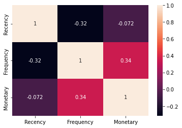

```python
sns.heatmap(rfm_data.corr(),annot=True)
```

On one hand, we have a negative correlation between:

- Recency and Frequency
- Recency and Monetary

On the other hand, the correlation between **Monetary and Frequency** is positive comparing to negative ones but still not that strong.

#### Visualize feature distributions

To get a better understanding of the dataset, we can construct a scatter matrix of each of the three features present in the RFM data.

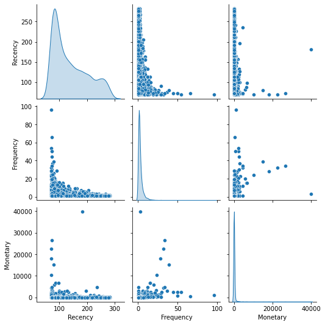

```python
import seaborn as sns
sns.pairplot(rfm_data,diag_kind='kde')
```

```python
rfm_data.skew()
```

```
Recency       0.750104
Frequency     7.825344
Monetary     23.221858
dtype: float64
```

We can notice that we have a **skewed distribution** of the 3 variables and there exist **outliers**.

This indicates how normalization is required to make the data features normally distributed as **clustering** algorithms **require** them to be **normally distributed**.

#### Data Normalization

```python
#log transformation
rfm_r_log = np.log(rfm_data['Recency']+0.1) #can't take log(0) and so add a small number
rfm_f_log = np.log(rfm_data['Frequency'])
rfm_m_log = np.log(rfm_data['Monetary']+0.1)
```

```python
log_data = pd.DataFrame({'Monetary': rfm_m_log,'Recency': rfm_r_log,'Frequency': rfm_f_log})
```

```python
log_data.head()
```

| CustomerID | Monetary | Recency | Frequency |
| --- | --- | --- | --- |
| 12747.0 | 5.257235 | 4.692265 | 1.609438 |
| 12748.0 | 6.960850 | 4.249923 | 4.564348 |
| 12749.0 | 4.206184 | 4.868303 | 1.098612 |
| 12820.0 | 2.714695 | 4.305416 | 0.000000 |
| 12821.0 | 2.996732 | 5.366443 | 0.000000 |

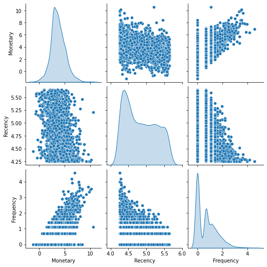

```python
# Produce a scatter matrix for each pair of features in the data
sns.pairplot(log_data,diag_kind='kde');
```

```python
log_data.skew()
```

```
Monetary     0.457588
Recency      0.302115
Frequency    0.989120
dtype: float64
```

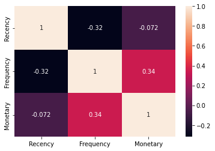

```python
sns.heatmap(rfm_data.corr(),annot=True)
```

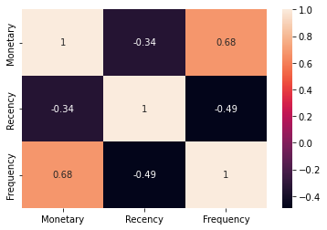

```python
sns.heatmap(log_data.corr(),annot=True)
```

```python
log_data.corr()
```

|  | Monetary | Recency | Frequency |
| --- | --- | --- | --- |
| Monetary | 1.000000 | -0.341600 | 0.680153 |
| Recency | -0.341600 | 1.000000 | -0.488678 |
| Frequency | 0.680153 | -0.488678 | 1.000000 |

Now, Monetary and Frequency are more strongly correlated.

### K-means Implementation

A common challenge with k-means is that you must tell it how many clusters you expect. Figuring out how many clusters we need is not obvious from data, thus we will try different clusters numbers and check their [silhouette coefficient](http://scikit-learn.org/stable/auto_examples/cluster/plot_kmeans_silhouette_analysis.html). The silhouette coefficient for a data point measures how similar it is to its assigned cluster from -1 (dissimilar) to 1 (similar). The [elbow](https://en.wikipedia.org/wiki/Determining_the_number_of_clusters_in_a_data_set#The_elbow_method) method can be used to determine the number of clusters as well.

**Note:** K-means is sensitive to initializations because those initializations are critical to quality of optima found. Thus, we will use smart initialization called *k-means++*.

```python
X=log_data
```

```python
from sklearn.cluster import KMeans
# Let us check optimal number of clusters-
cluster_range = range( 1, 15)
cluster_errors = []
cluster_sil_scores = []
for num_clusters in cluster_range:
  clusters = KMeans( num_clusters, n_init = 100,init='k-means++',random_state=0)
  clusters.fit(X)
  labels = clusters.labels_                     # capture the cluster lables
  centroids = clusters.cluster_centers_         # capture the centroids
  cluster_errors.append( clusters.inertia_ )    # capture the intertia
# combine the cluster_range and cluster_errors into a dataframe by combining them
clusters_df = pd.DataFrame( { "num_clusters":cluster_range, "cluster_errors": cluster_errors} )
clusters_df[0:10]
```

|  | num_clusters | cluster_errors |
| --- | --- | --- |
| 0 | 1 | 8086.128940 |
| 1 | 2 | 3804.745430 |
| 2 | 3 | 2688.258772 |
| 3 | 4 | 2156.143199 |
| 4 | 5 | 1787.252425 |
| 5 | 6 | 1528.554849 |
| 6 | 7 | 1367.456522 |
| 7 | 8 | 1224.449415 |
| 8 | 9 | 1090.499927 |
| 9 | 10 | 1010.191010 |

```python
errors = clusters_df['cluster_errors']
```

```python
for i in range(8):
    print(errors[i+1]-errors[i])
```

```
-4281.383510131023
-1116.4866575909855
-532.1155738541652
-368.8907736751221
-258.6975756601678
-161.0983269395026
-143.0071070018896
-133.94948799110784
```

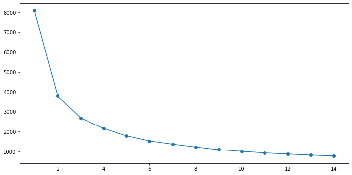

```python
# Elbow plot

plt.figure(figsize=(12,6))
plt.plot( clusters_df.num_clusters, clusters_df.cluster_errors, marker = "o" )
```

```python
# Number of clusters
kmeans = KMeans(n_clusters=2,n_init = 100,init='k-means++',random_state=0)
# Fitting the input data
kmeans = kmeans.fit(X)
# Getting the cluster labels
labels = kmeans.predict(X)
# Centroid values
centroids = kmeans.cluster_centers_
# Comparing with scikit-learn centroids
print("Centroid values")
print("sklearn")
print(centroids) # From sci-kit learn
```

```
Centroid values
sklearn
[[5.07801444 4.63228822 1.40576725]
 [2.8449754  4.96267116 0.29861244]]
```

```python
colnames = ["Monetary", "Recency","Frequency"]
prediction= kmeans.predict(X)
#X["clusters"] = prediction
X_df = pd.DataFrame(X, columns= colnames)
X_df["group"] = prediction
```

```python
X_df.head()
```

| CustomerID | Monetary | Recency | Frequency | group |
| --- | --- | --- | --- | --- |
| 12747.0 | 5.257235 | 4.692265 | 1.609438 | 0 |
| 12748.0 | 6.960850 | 4.249923 | 4.564348 | 0 |
| 12749.0 | 4.206184 | 4.868303 | 1.098612 | 0 |
| 12820.0 | 2.714695 | 4.305416 | 0.000000 | 1 |
| 12821.0 | 2.996732 | 5.366443 | 0.000000 | 1 |

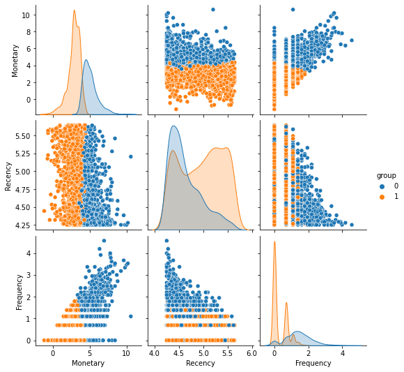

```python
sns.pairplot(X_df,diag_kind='kde',hue='group')
```

[output not shown]

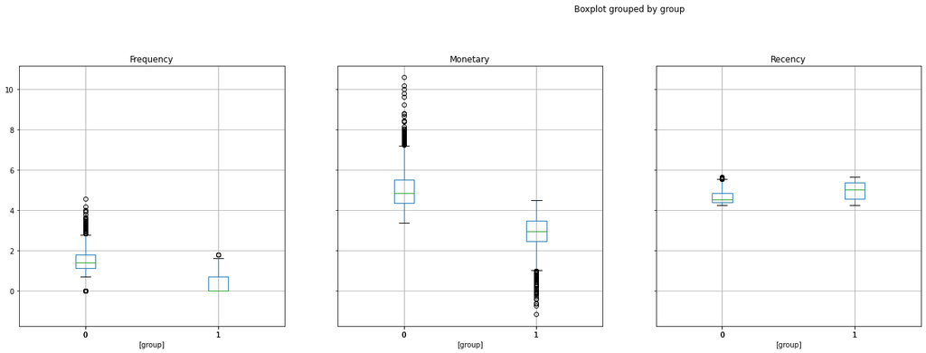

```python
X_df.boxplot(by = 'group',layout=(2,4), figsize=(30, 15))
```

```
Automatically created module for IPython interactive environment
For n_clusters = 2 The average silhouette_score is : 0.4552036958093268
```

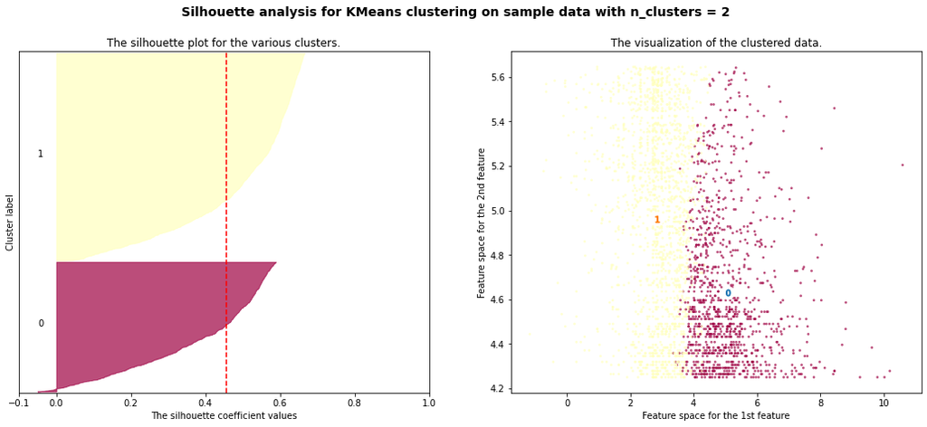

```
For n_clusters = 3 The average silhouette_score is : 0.36177534278060913
```

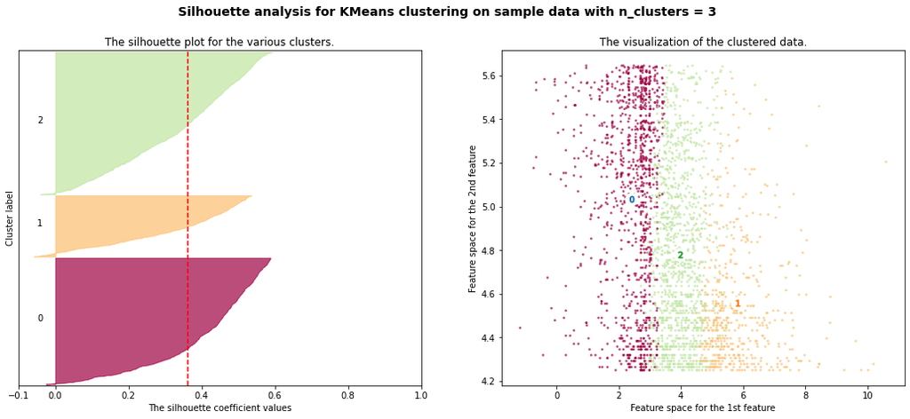

```
For n_clusters = 4 The average silhouette_score is : 0.33223674860823516
```

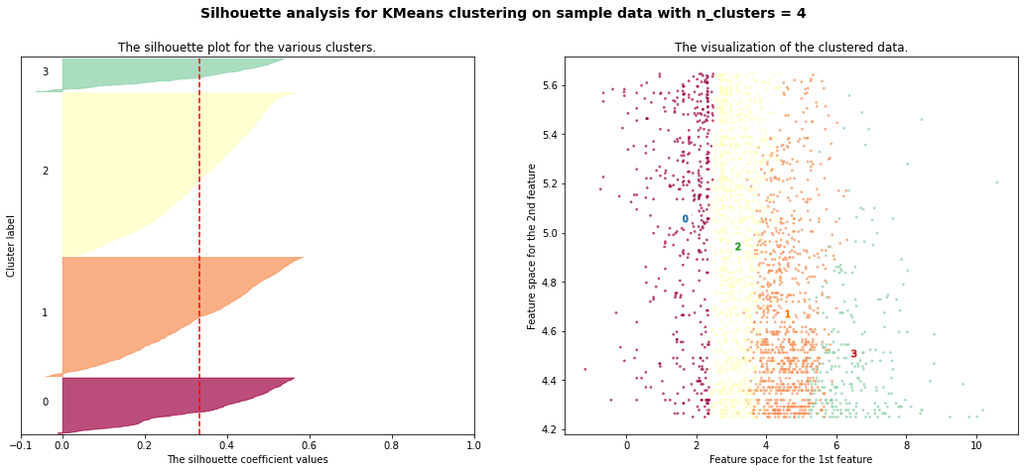

```
For n_clusters = 5 The average silhouette_score is : 0.3234123963105954
```

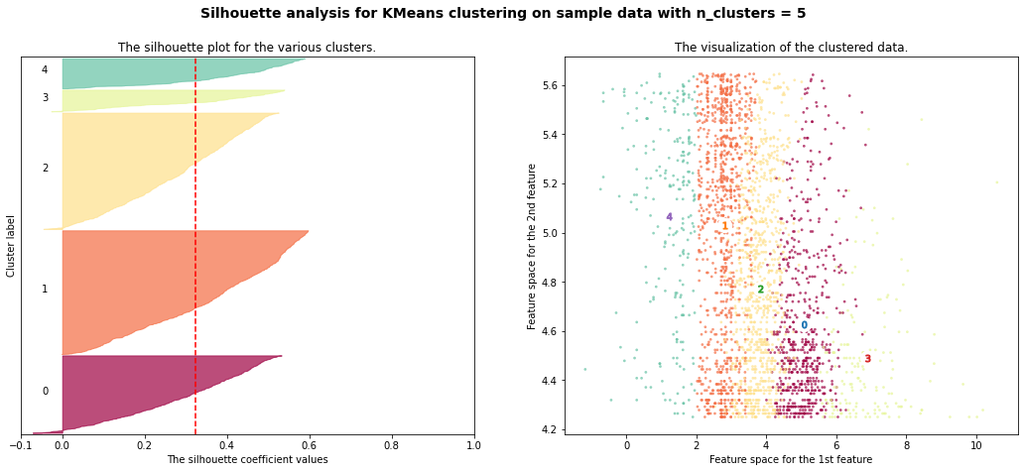

```
For n_clusters = 6 The average silhouette_score is : 0.3408494711132266
```

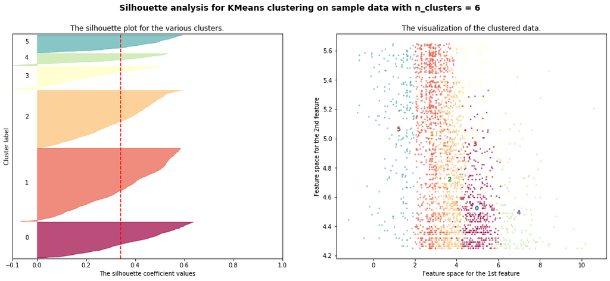

```
For n_clusters = 7 The average silhouette_score is : 0.32717710734264016
```

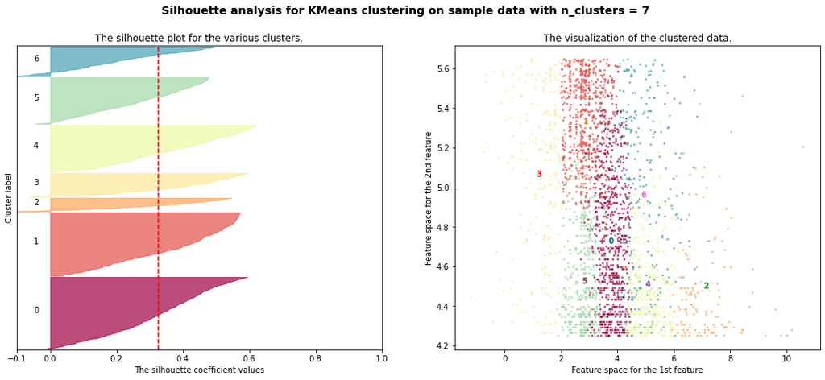

```python
from __future__ import print_function
%matplotlib inline

from sklearn.datasets import make_blobs
from sklearn.cluster import KMeans
from sklearn.metrics import silhouette_samples, silhouette_score

import matplotlib.pyplot as plt
import matplotlib.cm as cm
import numpy as np

print(__doc__)

# Generating the sample data from make_blobs
# This particular setting has one distinct cluster and 3 clusters placed close
# together.
X=X_df.drop('group',axis=1).values
y=X_df['group'].values

range_n_clusters = [2, 3, 4, 5, 6,7]

for n_clusters in range_n_clusters:
    # Create a subplot with 1 row and 2 columns
    fig, (ax1, ax2) = plt.subplots(1, 2)
    fig.set_size_inches(18, 7)

    # The 1st subplot is the silhouette plot
    # The silhouette coefficient can range from -1, 1 but in this example all
    # lie within [-0.1, 1]
    ax1.set_xlim([-0.1, 1])
    # The (n_clusters+1)*10 is for inserting blank space between silhouette
    # plots of individual clusters, to demarcate them clearly.
    ax1.set_ylim([0, len(X) + (n_clusters + 1) * 10])

    # Initialize the clusterer with n_clusters value and a random generator
    # seed of 10 for reproducibility.
    clusterer = KMeans(n_clusters=n_clusters,n_init = 100,init='k-means++',random_state=0)
    cluster_labels = clusterer.fit_predict(X)

    # The silhouette_score gives the average value for all the samples.
    # This gives a perspective into the density and separation of the formed
    # clusters
    silhouette_avg = silhouette_score(X, cluster_labels)
    print("For n_clusters =", n_clusters,
          "The average silhouette_score is :", silhouette_avg)

    # Compute the silhouette scores for each sample
    sample_silhouette_values = silhouette_samples(X, cluster_labels)

    y_lower = 10
    for i in range(n_clusters):
        # Aggregate the silhouette scores for samples belonging to
        # cluster i, and sort them
        ith_cluster_silhouette_values = \
            sample_silhouette_values[cluster_labels == i]

        ith_cluster_silhouette_values.sort()

        size_cluster_i = ith_cluster_silhouette_values.shape[0]
        y_upper = y_lower + size_cluster_i

        color = cm.Spectral(float(i) / n_clusters)
        ax1.fill_betweenx(np.arange(y_lower, y_upper),
                          0, ith_cluster_silhouette_values,
                          facecolor=color, edgecolor=color, alpha=0.7)

        # Label the silhouette plots with their cluster numbers at the middle
        ax1.text(-0.05, y_lower + 0.5 * size_cluster_i, str(i))

        # Compute the new y_lower for next plot
        y_lower = y_upper + 10  # 10 for the 0 samples

    ax1.set_title("The silhouette plot for the various clusters.")
    ax1.set_xlabel("The silhouette coefficient values")
    ax1.set_ylabel("Cluster label")

    # The vertical line for average silhouette score of all the values
    ax1.axvline(x=silhouette_avg, color="red", linestyle="--")

    ax1.set_yticks([])  # Clear the yaxis labels / ticks
    ax1.set_xticks([-0.1, 0, 0.2, 0.4, 0.6, 0.8, 1])

    # 2nd Plot showing the actual clusters formed
    colors = cm.Spectral(cluster_labels.astype(float) / n_clusters)
    ax2.scatter(X[:, 0], X[:, 1], marker='.', s=30, lw=0, alpha=0.7,
                c=colors)

    # Labeling the clusters
    centers = clusterer.cluster_centers_
    # Draw white circles at cluster centers
    ax2.scatter(centers[:, 0], centers[:, 1],
                marker='o', c="white", alpha=1, s=200)

    for i, c in enumerate(centers):
        ax2.scatter(c[0], c[1], marker='$%d$' % i, alpha=1, s=50)

    ax2.set_title("The visualization of the clustered data.")
    ax2.set_xlabel("Feature space for the 1st feature")
    ax2.set_ylabel("Feature space for the 2nd feature")

    plt.suptitle(("Silhouette analysis for KMeans clustering on sample data "
                  "with n_clusters = %d" % n_clusters),
                 fontsize=14, fontweight='bold')

    plt.show()
```

```python
from sklearn.cluster import AgglomerativeClustering
```

```python
model2 = AgglomerativeClustering(n_clusters=2, affinity='euclidean',  linkage='ward')
```

```python
model2.fit(X)
```

```
AgglomerativeClustering()
```

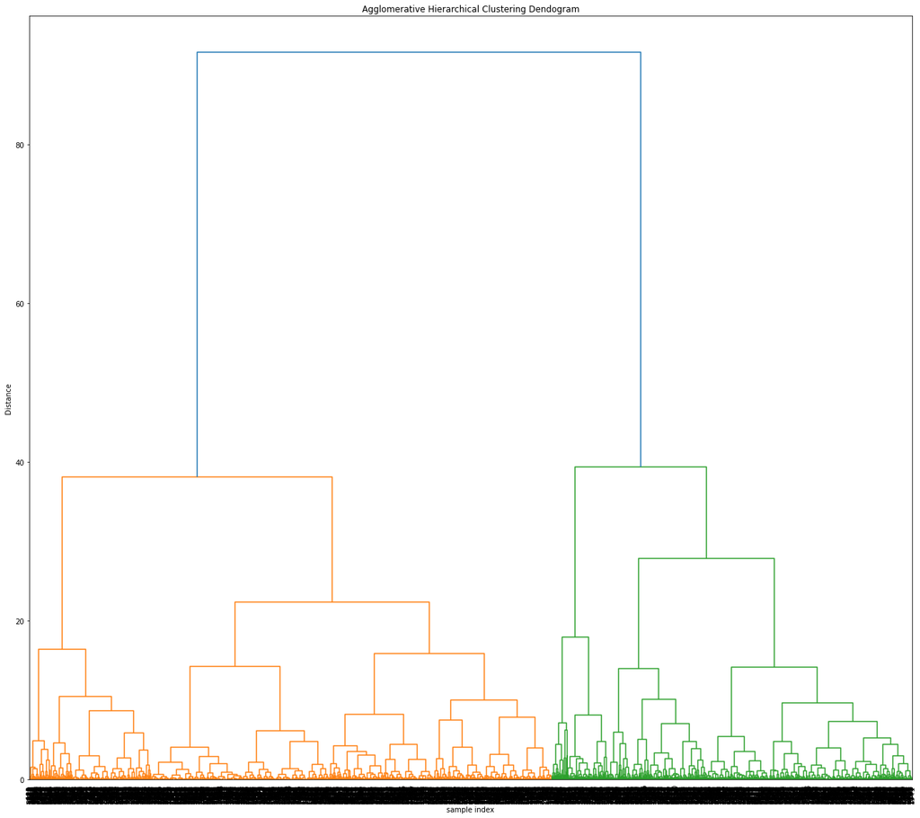

```python
from scipy.cluster.hierarchy import dendrogram, linkage
from scipy.spatial.distance import pdist
plt.figure(figsize=(18, 16))
plt.title('Agglomerative Hierarchical Clustering Dendogram')
plt.xlabel('sample index')
plt.ylabel('Distance')
Z = linkage(X, 'ward')
dendrogram(Z,leaf_rotation=90.0,p=25,color_threshold=80,leaf_font_size=10,truncate_mode='level')
plt.tight_layout()
```

```python
#Applying PCA
X=log_data
pca=PCA(n_components=2)
X = pca.fit_transform(X)
```

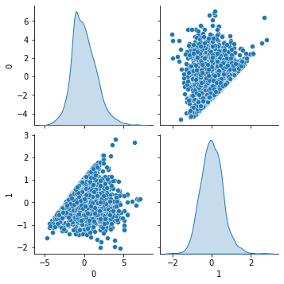

```python
sns.pairplot(pd.DataFrame(X),diag_kind='kde')
```

```python
pca.explained_variance_ratio_
```

```
array([0.8440501 , 0.11114047])
```

```python
from sklearn.cluster import KMeans
# Let us check optimal number of clusters-
cluster_range = range( 1, 15)
cluster_errors = []
cluster_sil_scores = []
for num_clusters in cluster_range:
  clusters = KMeans( num_clusters, n_init = 100,init='k-means++',random_state=0)
  clusters.fit(X)
  labels = clusters.labels_                     # capture the cluster lables
  centroids = clusters.cluster_centers_         # capture the centroids
  cluster_errors.append( clusters.inertia_ )    # capture the intertia
# combine the cluster_range and cluster_errors into a dataframe by combining them
clusters_df = pd.DataFrame( { "num_clusters":cluster_range, "cluster_errors": cluster_errors} )
clusters_df[0:10]
```

|  | num_clusters | cluster_errors |
| --- | --- | --- |
| 0 | 1 | 7723.794110 |
| 1 | 2 | 3442.438585 |
| 2 | 3 | 2328.232454 |
| 3 | 4 | 1799.757806 |
| 4 | 5 | 1432.000391 |
| 5 | 6 | 1174.665812 |
| 6 | 7 | 1018.534710 |
| 7 | 8 | 874.216330 |
| 8 | 9 | 777.935314 |
| 9 | 10 | 699.635895 |

```python
errors = clusters_df['cluster_errors']
```

```python
for i in range(8):
    print(errors[i+1]-errors[i])
```

```
-4281.355525015677
-1114.2061312584656
-528.4746478491675
-367.7574152195002
-257.33457836126536
-156.13110262397038
-144.3183800927103
-96.28101528826642
```

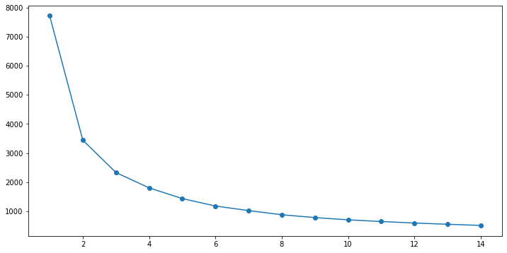

```python
# Elbow plot

plt.figure(figsize=(12,6))
plt.plot( clusters_df.num_clusters, clusters_df.cluster_errors, marker = "o" )
```

```python
# Number of clusters
kmeans = KMeans(n_clusters=2,n_init = 100,init='k-means++',random_state=0)
# Fitting the input data
kmeans = kmeans.fit(X)
# Getting the cluster labels
labels = kmeans.predict(X)
# Centroid values
centroids = kmeans.cluster_centers_
# Comparing with scikit-learn centroids
print("Centroid values")
print("sklearn")
print(centroids) # From sci-kit learn
```

```
Centroid values
sklearn
[[ 1.54666586 -0.0712699 ]
 [-0.96447418  0.04444268]]
```

```python
colnames = ["PC1", "PC2"]
prediction= kmeans.predict(X)
#X["clusters"] = prediction
X_df = pd.DataFrame(X, columns= colnames)
X_df["group"] = prediction
```

```python
X_df.head()
```

|  | PC1 | PC2 | group |
| --- | --- | --- | --- |
| 0 | 1.785544 | -0.140606 | 0 |
| 1 | 4.572856 | -2.039909 | 0 |
| 2 | 0.605105 | -0.087506 | 0 |
| 3 | -1.125622 | -0.017999 | 1 |
| 4 | -0.993182 | 0.508629 | 1 |

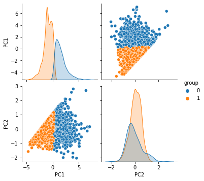

```python
sns.pairplot(X_df,diag_kind='kde',hue='group')
```

[output not shown]

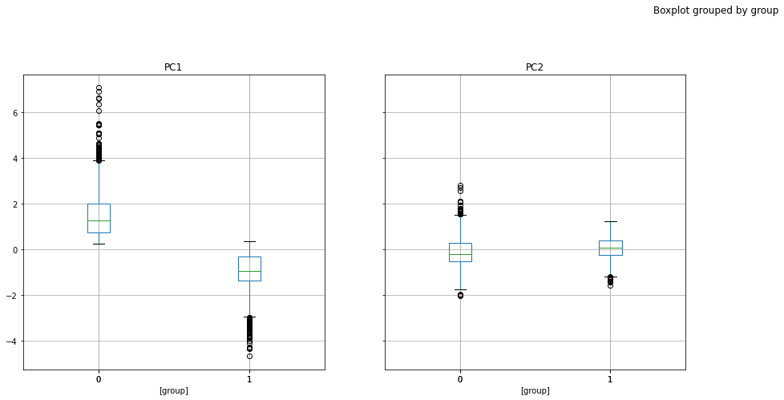

```python
X_df.boxplot(by = 'group',layout=(2,4), figsize=(30, 15))
```

```
Automatically created module for IPython interactive environment
For n_clusters = 2 The average silhouette_score is : 0.48842281325054226
```

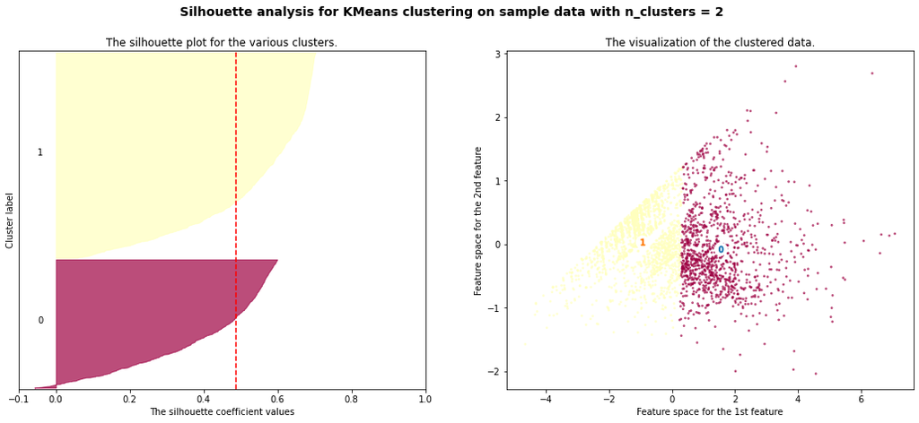

```
For n_clusters = 3 The average silhouette_score is : 0.4070186928147123
```

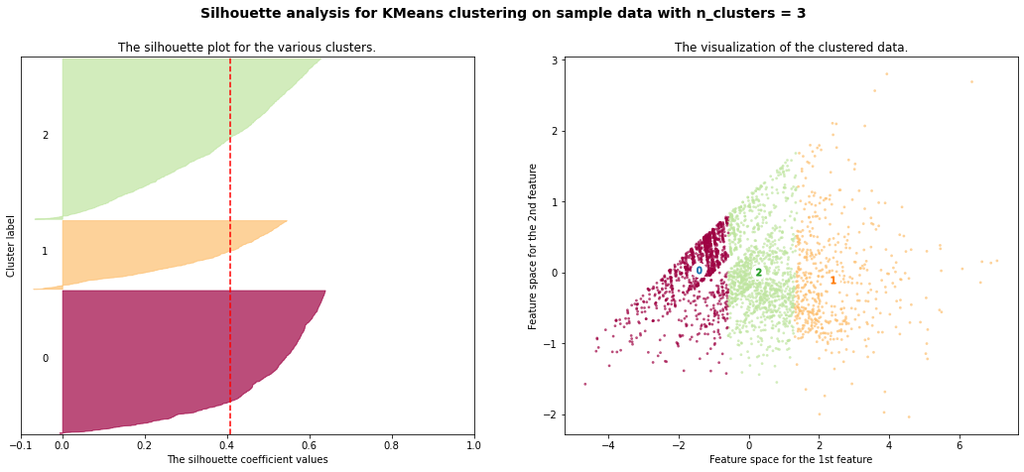

```
For n_clusters = 4 The average silhouette_score is : 0.3827264355439567
```

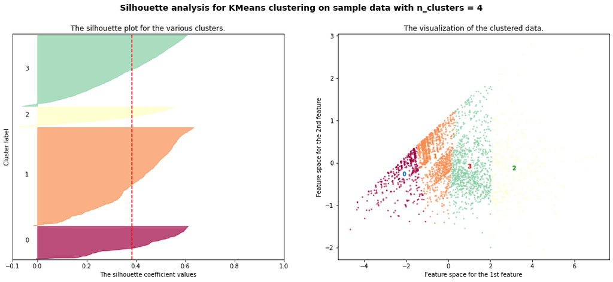

```
For n_clusters = 5 The average silhouette_score is : 0.3834185839377743
```

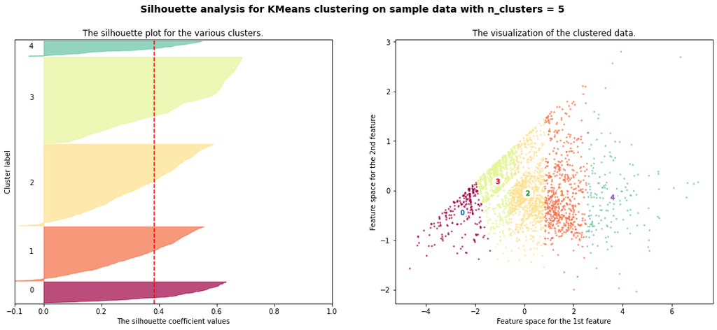

```
For n_clusters = 6 The average silhouette_score is : 0.4055457522648199
```

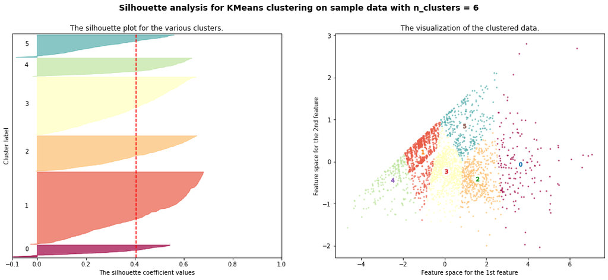

```
For n_clusters = 7 The average silhouette_score is : 0.3694143567158102
```

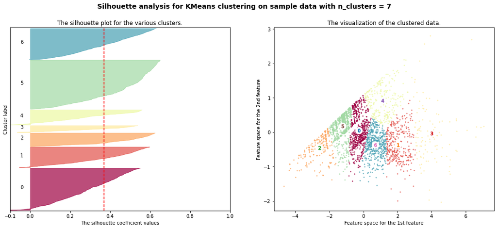

```python
from __future__ import print_function
%matplotlib inline

from sklearn.datasets import make_blobs
from sklearn.cluster import KMeans
from sklearn.metrics import silhouette_samples, silhouette_score

import matplotlib.pyplot as plt
import matplotlib.cm as cm
import numpy as np

print(__doc__)

# Generating the sample data from make_blobs
# This particular setting has one distinct cluster and 3 clusters placed close
# together.
X=X_df.drop('group',axis=1).values
y=X_df['group'].values

range_n_clusters = [2, 3, 4, 5, 6,7]

for n_clusters in range_n_clusters:
    # Create a subplot with 1 row and 2 columns
    fig, (ax1, ax2) = plt.subplots(1, 2)
    fig.set_size_inches(18, 7)

    # The 1st subplot is the silhouette plot
    # The silhouette coefficient can range from -1, 1 but in this example all
    # lie within [-0.1, 1]
    ax1.set_xlim([-0.1, 1])
    # The (n_clusters+1)*10 is for inserting blank space between silhouette
    # plots of individual clusters, to demarcate them clearly.
    ax1.set_ylim([0, len(X) + (n_clusters + 1) * 10])

    # Initialize the clusterer with n_clusters value and a random generator
    # seed of 10 for reproducibility.
    clusterer = KMeans(n_clusters=n_clusters,n_init = 100,init='k-means++',random_state=0)
    cluster_labels = clusterer.fit_predict(X)

    # The silhouette_score gives the average value for all the samples.
    # This gives a perspective into the density and separation of the formed
    # clusters
    silhouette_avg = silhouette_score(X, cluster_labels)
    print("For n_clusters =", n_clusters,
          "The average silhouette_score is :", silhouette_avg)

    # Compute the silhouette scores for each sample
    sample_silhouette_values = silhouette_samples(X, cluster_labels)

    y_lower = 10
    for i in range(n_clusters):
        # Aggregate the silhouette scores for samples belonging to
        # cluster i, and sort them
        ith_cluster_silhouette_values = \
            sample_silhouette_values[cluster_labels == i]

        ith_cluster_silhouette_values.sort()

        size_cluster_i = ith_cluster_silhouette_values.shape[0]
        y_upper = y_lower + size_cluster_i

        color = cm.Spectral(float(i) / n_clusters)
        ax1.fill_betweenx(np.arange(y_lower, y_upper),
                          0, ith_cluster_silhouette_values,
                          facecolor=color, edgecolor=color, alpha=0.7)

        # Label the silhouette plots with their cluster numbers at the middle
        ax1.text(-0.05, y_lower + 0.5 * size_cluster_i, str(i))

        # Compute the new y_lower for next plot
        y_lower = y_upper + 10  # 10 for the 0 samples

    ax1.set_title("The silhouette plot for the various clusters.")
    ax1.set_xlabel("The silhouette coefficient values")
    ax1.set_ylabel("Cluster label")

    # The vertical line for average silhouette score of all the values
    ax1.axvline(x=silhouette_avg, color="red", linestyle="--")

    ax1.set_yticks([])  # Clear the yaxis labels / ticks
    ax1.set_xticks([-0.1, 0, 0.2, 0.4, 0.6, 0.8, 1])

    # 2nd Plot showing the actual clusters formed
    colors = cm.Spectral(cluster_labels.astype(float) / n_clusters)
    ax2.scatter(X[:, 0], X[:, 1], marker='.', s=30, lw=0, alpha=0.7,
                c=colors)

    # Labeling the clusters
    centers = clusterer.cluster_centers_
    # Draw white circles at cluster centers
    ax2.scatter(centers[:, 0], centers[:, 1],
                marker='o', c="white", alpha=1, s=200)

    for i, c in enumerate(centers):
        ax2.scatter(c[0], c[1], marker='$%d$' % i, alpha=1, s=50)

    ax2.set_title("The visualization of the clustered data.")
    ax2.set_xlabel("Feature space for the 1st feature")
    ax2.set_ylabel("Feature space for the 2nd feature")

    plt.suptitle(("Silhouette analysis for KMeans clustering on sample data "
                  "with n_clusters = %d" % n_clusters),
                 fontsize=14, fontweight='bold')

    plt.show()
```

```python
from sklearn.cluster import AgglomerativeClustering
```

```python
model2 = AgglomerativeClustering(n_clusters=2, affinity='euclidean',  linkage='ward')
```

```python
model2.fit(X)
```

```
AgglomerativeClustering()
```

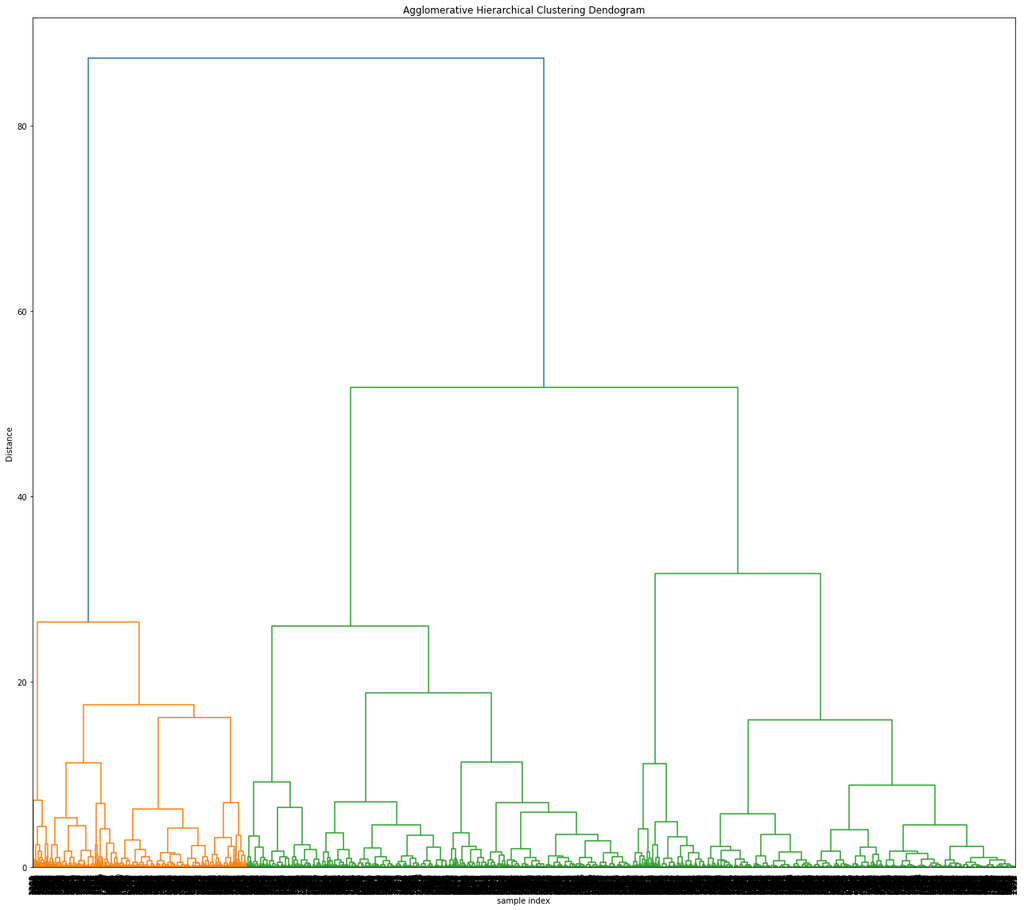

```python
from scipy.cluster.hierarchy import dendrogram, linkage
from scipy.spatial.distance import pdist
plt.figure(figsize=(18, 16))
plt.title('Agglomerative Hierarchical Clustering Dendogram')
plt.xlabel('sample index')
plt.ylabel('Distance')
Z = linkage(X, 'ward')
dendrogram(Z,leaf_rotation=90.0,p=25,color_threshold=80,leaf_font_size=10,truncate_mode='level')
plt.tight_layout()
```

```python
#Applying PCA
X=log_data
pca=PCA(n_components=1)
X = pca.fit_transform(X)
```

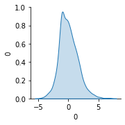

```python
sns.pairplot(pd.DataFrame(X),diag_kind='kde')
```

```python
pca.explained_variance_ratio_
```

```
array([0.8440501])
```

```python
pca.components_
```

```
array([[ 0.90805597, -0.11655248,  0.40230569]])
```

```python
from sklearn.cluster import KMeans
# Let us check optimal number of clusters-
cluster_range = range( 1, 15)
cluster_errors = []
cluster_sil_scores = []
for num_clusters in cluster_range:
  clusters = KMeans( num_clusters, n_init = 100,init='k-means++',random_state=0)
  clusters.fit(X)
  labels = clusters.labels_                     # capture the cluster lables
  centroids = clusters.cluster_centers_         # capture the centroids
  cluster_errors.append( clusters.inertia_ )    # capture the intertia
# combine the cluster_range and cluster_errors into a dataframe by combining them
clusters_df = pd.DataFrame( { "num_clusters":cluster_range, "cluster_errors": cluster_errors} )
clusters_df[0:10]
```

|  | num_clusters | cluster_errors |
| --- | --- | --- |
| 0 | 1 | 6825.097964 |
| 1 | 2 | 2551.572794 |
| 2 | 3 | 1434.824732 |
| 3 | 4 | 937.530011 |
| 4 | 5 | 602.050771 |
| 5 | 6 | 427.100823 |
| 6 | 7 | 332.047341 |
| 7 | 8 | 257.803874 |
| 8 | 9 | 203.405361 |
| 9 | 10 | 170.148360 |

```python
errors = clusters_df['cluster_errors']
```

```python
for i in range(8):
    print(errors[i+1]-errors[i])
```

```
-4273.52516957578
-1116.7480619163935
-497.2947215809297
-335.4792397406952
-174.9499482035817
-95.05348204279562
-74.24346639586389
-54.39851282365507
```

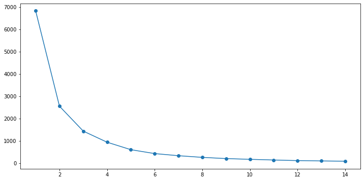

```python
# Elbow plot

plt.figure(figsize=(12,6))
plt.plot( clusters_df.num_clusters, clusters_df.cluster_errors, marker = "o" )
```

```python
# Number of clusters
kmeans = KMeans(n_clusters=3,n_init = 100,init='k-means++',random_state=0)
# Fitting the input data
kmeans = kmeans.fit(X)
# Getting the cluster labels
labels = kmeans.predict(X)
# Centroid values
centroids = kmeans.cluster_centers_
# Comparing with scikit-learn centroids
print("Centroid values")
print("sklearn")
print(centroids) # From sci-kit learn
```

```
Centroid values
sklearn
[[-1.45637799]
 [ 2.34843402]
 [ 0.2519544 ]]
```

```python
colnames = ["PC1"]
prediction= kmeans.predict(X)
#X["clusters"] = prediction
X_df = pd.DataFrame(X, columns= colnames)
X_df["group"] = prediction
```

```python
X_df.head()
```

|  | PC1 | group |
| --- | --- | --- |
| 0 | 1.785544 | 1 |
| 1 | 4.572856 | 1 |
| 2 | 0.605105 | 2 |
| 3 | -1.125622 | 0 |
| 4 | -0.993182 | 0 |

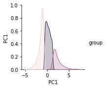

```python
sns.pairplot(X_df,diag_kind='kde',hue='group')
```

[output not shown]

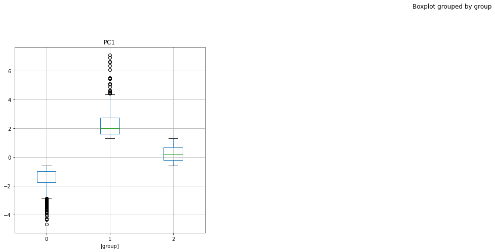

```python
X_df.boxplot(by = 'group',layout=(2,4), figsize=(30, 15))
```

```python
from __future__ import print_function
%matplotlib inline

from sklearn.datasets import make_blobs
from sklearn.cluster import KMeans
from sklearn.metrics import silhouette_samples, silhouette_score

import matplotlib.pyplot as plt
import matplotlib.cm as cm
import numpy as np

print(__doc__)

# Generating the sample data from make_blobs
# This particular setting has one distinct cluster and 3 clusters placed close
# together.
X=X_df.drop('group',axis=1).values
y=X_df['group'].values

range_n_clusters = [2, 3, 4, 5, 6,7]

for n_clusters in range_n_clusters:
    clusterer = KMeans(n_clusters=n_clusters,n_init = 100,init='k-means++',random_state=0)
    cluster_labels = clusterer.fit_predict(X)

    # The silhouette_score gives the average value for all the samples.
    # This gives a perspective into the density and separation of the formed
    # clusters
    silhouette_avg = silhouette_score(X, cluster_labels)
    print("For n_clusters =", n_clusters,
          "The average silhouette_score is :", silhouette_avg)

    # Compute the silhouette scores for each sample
    sample_silhouette_values = silhouette_samples(X, cluster_labels)
```

```
Automatically created module for IPython interactive environment
For n_clusters = 2 The average silhouette_score is : 0.5708794031056077
For n_clusters = 3 The average silhouette_score is : 0.5296283163817164
For n_clusters = 4 The average silhouette_score is : 0.5245678421437782
For n_clusters = 5 The average silhouette_score is : 0.5387904854901109
For n_clusters = 6 The average silhouette_score is : 0.5434602660557293
For n_clusters = 7 The average silhouette_score is : 0.5391400401402437
```

```python
from sklearn.cluster import AgglomerativeClustering
```

```python
model2 = AgglomerativeClustering(n_clusters=2, affinity='euclidean',  linkage='ward')
```

```python
model2.fit(X)
```

```
AgglomerativeClustering()
```

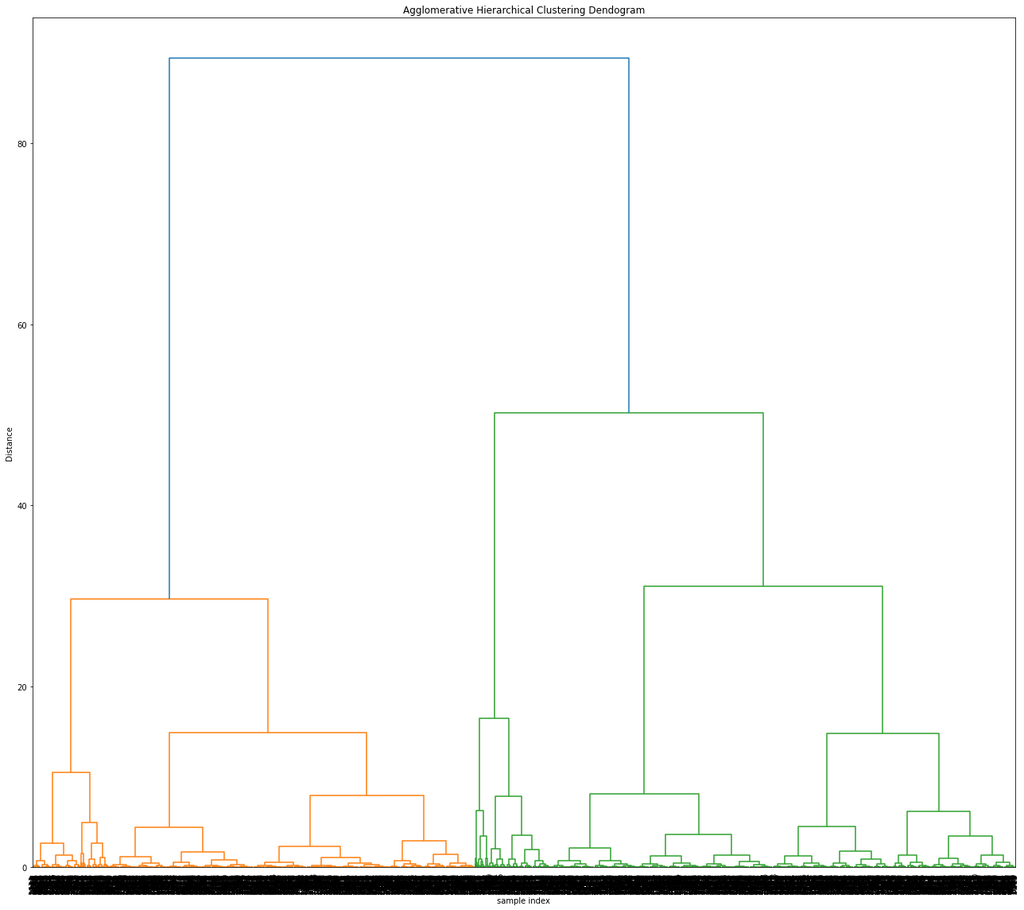

```python
from scipy.cluster.hierarchy import dendrogram, linkage
from scipy.spatial.distance import pdist
plt.figure(figsize=(18, 16))
plt.title('Agglomerative Hierarchical Clustering Dendogram')
plt.xlabel('sample index')
plt.ylabel('Distance')
Z = linkage(X, 'ward')
dendrogram(Z,leaf_rotation=90.0,p=25,color_threshold=60,leaf_font_size=10,truncate_mode='level')
plt.tight_layout()
```

The **best silhouette score** obtained is when the **number of clusters is 2**.

**Conclusion - Perspective after applying k-means clustering**:

Unfortunately, we didn't obtain a clearly separated clusters. Clusters assignments are muddled. (It may be due to outliers who weren't removed).

Limitations of k-means clustering:

- There is no assurance that it will lead to the *global* best solution.
- Can't deal with **different shapes**(not circular) and consider one point's probability of belonging to more than one cluster.

These disadvantages of k-means mean that for many datasets (especially low-dimensional datasets) it may not perform as well as you might hope. Here comes Guassian Mixture Model (GMM) in help by providing greater flexibility due to clusters having unconstrained covariances and allowing probabilistic cluster assignment.

Reference *Python Data Science Handbook* by *Jake VanderPlas*.

### Conclusion - Perspectives

At this juncture, it makes sense to show interested stakeholders the cluster solutions and get their input. The decision should be based upon how the business plans to use the results, and the **level of granularity** they want to see in the clusters. What range of customer behavior from high-to-low value customers are the business stakeholders interested in exploring? And from the answer to that question various methods of clustering can be further exploited whether applied on RFM variables or directly on the transaction dataset available.

If I have more time, I will do Classification for future customers in appropriate defined clusters by trying different models like SVC, Logistic Regression on training set and compare their performance on the test set in order to choose the best one to use for our predictions.